# K-Means Simulator Pitch

August 27, 2017

## K-Means clustering

The K-Means clustering algorithm is an algorithm used for clustering data points. It is a good algoritm, but it depends on knowing the correct number of centers, or clusters, to start with in order to get the best results.

## The algorithm

The algorithm starts k, the selected number of centers, randomly placed points, and then each data points is 'assigned' to the center to which it is closest, forming a temporary cluster. To proceed, the centers are moved to the center of their temporary clusters, and then the process is repeated.

## Non-deterministic

Due to the fact that the algorithm starts with randomized points, it is non-deterministic. Running the algorithm on the same data set, with the same parameters, can result in different clustering.

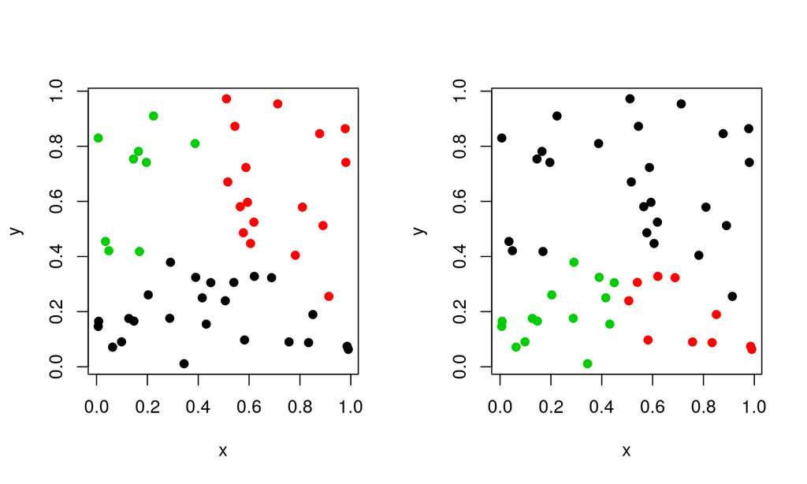

## K-Means Simulation

My simulator allows you to create a random set of data points, which is customizable with the use of the panel for specifing the generators parameters. Once generated, you can set the number of centers for the k-means algorithm and run it to see the results. You can re-run the algorithm without changing the data points to see how different results can often be obtained.

The simulator can be found at [K-Means Simulator](https://ralph7c2.shinyapps.io/k-means_simulator/)